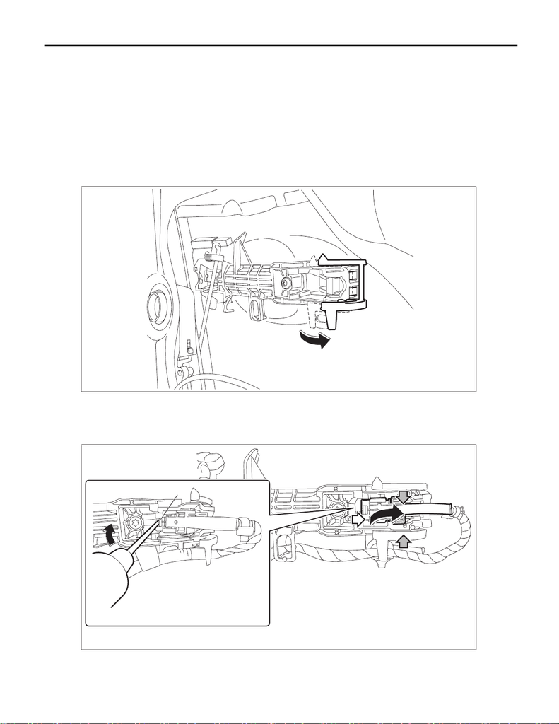

SL-33

Front Outer Handle

SECURITY AND LOCKS

9. Front Outer Handle

A: REMOVAL

1) Raise the glass assembly - front door to the top position.

2) Disconnect the ground cable from battery and wait for at least 60 seconds before starting work. <Ref. to

NT-5, BATTERY, NOTE, Note.>

NOTE:

For models other than STI model, disconnect the ground terminal from battery sensor.

3) Remove the trim panel - front door. <Ref. to EI-56, FRONT DOOR, REMOVAL, Door Trim.>

4) Remove the sealing cover - front door. <Ref. to EB-32, REMOVAL, Front Sealing Cover.>

5) Remove the holder of the frame assembly - front door outer.

NOTE:

• For model with keyless access, disconnect the harness clip and exterior antenna (touch sensor) connec-

tor.

• Using (a) shown in the figure as a supporting point, pry it with a flat tip screwdriver to remove.

SL-01447

SL-02397

(a)

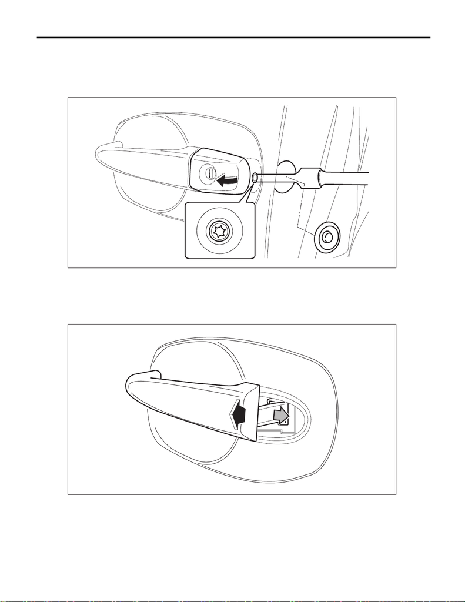

SL-34

Front Outer Handle

SECURITY AND LOCKS

6) Remove the cover - handle front outer.

Preparation tool:

TORX

®

T30

(1) Remove the plug at the rear end of the panel assembly - front door.

(2) Loosen the TORX

®

bolt and remove the cover - handle front outer.

7) Remove the handle - door outer.

CAUTION:

Do not apply excessive force to remove the handle - door outer from the frame assembly - front door.

(1) Pull the handle - door outer rearward to release engagement of the frame assembly - front door outer.

(2) Pull the handle - door outer towards yourself to remove the handle - door outer.

SL-01175

SL-01176

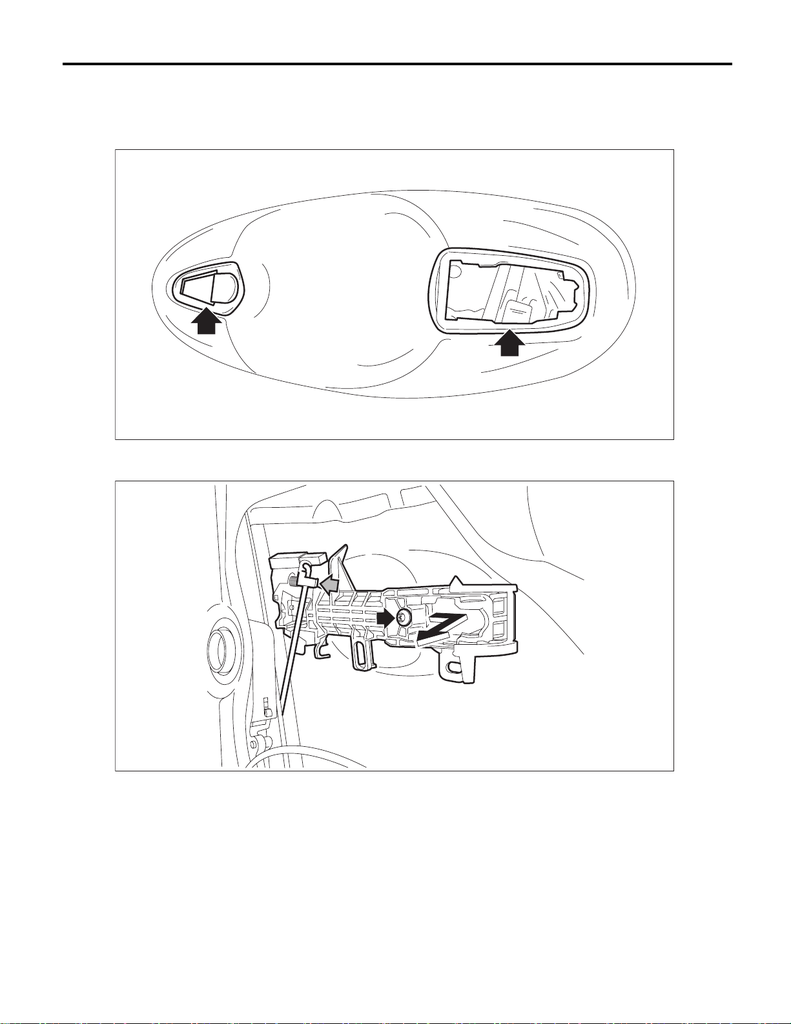

SL-35

Front Outer Handle

SECURITY AND LOCKS

8) Remove the frame assembly - front door outer.

Preparation tool:

TORX

®

T30

(1) Remove the spacer - door handle outer.

(2) Remove the rod clamp and remove the rod.

(3) Loosen the TORX

®

bolt and remove the frame assembly - front door outer.

SL-01177

SL-01448

[figure not shown]

SL-36

Front Outer Handle

SECURITY AND LOCKS

B: INSTALLATION

1) Before installation, check the following items.

• Rod is free from deformation.

• Grease is applied sufficiently to rod joints.

If grease is insufficient, add it as necessary before assembling the rod.

2) Install the frame assembly - front door outer.

Preparation tool:

TORX

®

T30

Tightening torque:

7.5 N·m (0.8 kgf-m, 5.5 ft-lb)

Tightening torque:

Refer to “COMPONENT” of “General Description”. <Ref. to SL-2, DOOR LOCK ASSEMBLY, COM-

PONENT, General Description.>

3) Install the spacer - door handle outer.

4) Install the handle - door outer.

NOTE:

For model with keyless access, connect the harness clip and exterior antenna (touch sensor) connector.

(1) Insert the end of the handle - door outer to the frame assembly - front door outer.

(2) Push forward while inserting the rear end of the handle - door outer to the frame assembly - front door

outer.

5) Install the cover - handle front outer.

CAUTION:

When installing the cover - handle front outer on driver’s side, make sure that the key cylinder shaft

is correctly inserted into the latch & actuator assembly - front.

Preparation tool:

TORX

®

T30

Tightening torque:

7.5 N·m (0.8 kgf-m, 5.5 ft-lb)

6) Install the sealing cover - front door.

7) Install the trim panel - front door.

8) Connect the battery ground terminal. <Ref. to NT-5, BATTERY, NOTE, Note.>

NOTE:

For models other than STI model, connect the ground terminal to battery sensor.

C: INSPECTION

Check if the outer handle operates normally.

• If the lever is faulty, replace the handle - door outer.

• If the rod is deformed, replace the latch & actuator assembly - front.